# Homework 5

## Problem 1

### 1.1

Train a classification tree:

```r
library(rpart)
load("../HW03/zip.RData")
set.seed(10)
dat.tree <- rpart(V1 ~ ., data=dat$train, method="class", control=rpart.control(cp=0.0001))
print(dat.tree)
```

```
## n= 2219
##
## node), split, n, loss, yval, (yprob)
##       * denotes terminal node
##
##   1) root 2219 1214 1 (0.452906715 0.296529968 0.250563317)
##     2) V185>=-0.0015 1021   37 1 (0.963761019 0.014691479 0.021547502)
##       4) V45< -0.8665 989    6 1 (0.993933266 0.001011122 0.005055612)
##         8) V189< -0.686 981    0 1 (1.000000000 0.000000000 0.000000000) *
##         9) V189>=-0.686 8    3 5 (0.250000000 0.125000000 0.625000000) *
##       5) V45>=-0.8665 32   15 5 (0.031250000 0.437500000 0.531250000)
##        10) V108>=0.5705 13    1 3 (0.000000000 0.923076923 0.076923077) *
##        11) V108< 0.5705 19    3 5 (0.052631579 0.105263158 0.842105263) *
##     3) V185< -0.0015 1198  555 3 (0.017529215 0.536727880 0.445742905)
##       6) V77>=-0.9915 650   88 3 (0.000000000 0.864615385 0.135384615)
##        12) V86< 0.232 580   33 3 (0.000000000 0.943103448 0.056896552)
##          24) V25>=-0.989 560   17 3 (0.000000000 0.969642857 0.030357143)
##            48) V72< 0.9925 548    7 3 (0.000000000 0.987226277 0.012773723) *
##            49) V72>=0.9925 12    2 5 (0.000000000 0.166666667 0.833333333) *
##          25) V25< -0.989 20    4 5 (0.000000000 0.200000000 0.800000000)
##            50) V29< -0.738 7    3 3 (0.000000000 0.571428571 0.428571429) *
##            51) V29>=-0.738 13    0 5 (0.000000000 0.000000000 1.000000000) *
##        13) V86>=0.232 70   15 5 (0.000000000 0.214285714 0.785714286)
##          26) V55< -0.961 13    3 3 (0.000000000 0.769230769 0.230769231) *
##          27) V55>=-0.961 57    5 5 (0.000000000 0.087719298 0.912280702) *
##       7) V77< -0.9915 548  102 5 (0.038321168 0.147810219 0.813868613)
##        14) V71< -0.9995 149   81 5 (0.134228188 0.409395973 0.456375839)
##          28) V8>=0.2385 46    8 3 (0.021739130 0.826086957 0.152173913)
##            56) V15< -0.5115 39    1 3 (0.025641026 0.974358974 0.000000000) *
##            57) V15>=-0.5115 7    0 5 (0.000000000 0.000000000 1.000000000) *
##          29) V8< 0.2385 103   42 5 (0.184466019 0.223300971 0.592233010)
##            58) V186>=0.35 22    4 1 (0.818181818 0.045454545 0.136363636) *
##            59) V186< 0.35 81   23 5 (0.012345679 0.271604938 0.716049383)
##             118) V95>=-0.9115 7    0 3 (0.000000000 1.000000000 0.000000000) *
##             119) V95< -0.9115 74   16 5 (0.013513514 0.202702703 0.783783784)
##               238) V75>=-0.514 31   15 5 (0.000000000 0.483870968 0.516129032)
##                 476) V238< -0.6425 16    1 3 (0.000000000 0.937500000 0.062500000) *
##                 477) V238>=-0.6425 15    0 5 (0.000000000 0.000000000 1.000000000) *
##               239) V75< -0.514 43    1 5 (0.023255814 0.000000000 0.976744186) *
##        15) V71>=-0.9995 399   21 5 (0.002506266 0.050125313 0.947368421)
##          30) V95>=-0.4985 9    0 3 (0.000000000 1.000000000 0.000000000) *
##          31) V95< -0.4985 390   12 5 (0.002564103 0.028205128 0.969230769)
##            62) V75>=0.345 23    9 5 (0.043478261 0.347826087 0.608695652)
##             124) V207< 0.6585 12    4 3 (0.083333333 0.666666667 0.250000000) *
##             125) V207>=0.6585 11    0 5 (0.000000000 0.000000000 1.000000000) *
##            63) V75< 0.345 367    3 5 (0.000000000 0.008174387 0.991825613) *
```

```r
printcp(dat.tree)
```

```
##
## Classification tree:
## rpart(formula = V1 ~ ., data = dat$train, method = "class", control = rpart.control(cp = 1e-04))
##
## Variables actually used in tree construction:
##  [1] V108 V15  V185 V186 V189 V207 V238 V25  V29  V45  V55  V71  V72  V75
## [15] V77  V8   V86  V95
##
## Root node error: 1214/2219 = 0.54709
##
## n= 2219
##
##            CP nsplit rel error   xerror      xstd
## 1  0.51235585      0  1.000000 1.000000 0.0193150
## 2  0.30065898      1  0.487644 0.487644 0.0171616
## 3  0.03294893      2  0.186985 0.189456 0.0118273
## 4  0.01317957      3  0.154036 0.160626 0.0109856
## 5  0.01276771      4  0.140857 0.148270 0.0105937
## 6  0.01235585      6  0.115321 0.141680 0.0103759
## 7  0.00988468      7  0.102965 0.119440 0.0095894
## 8  0.00906096      8  0.093081 0.122735 0.0097114
## 9  0.00741351      9  0.084020 0.116145 0.0094653
## 10 0.00658979     10  0.076606 0.113674 0.0093708
## 11 0.00576606     11  0.070016 0.112850 0.0093391
## 12 0.00247117     16  0.041186 0.096376 0.0086719
## 13 0.00205931     17  0.038715 0.095552 0.0086368
## 14 0.00082372     19  0.034596 0.092257 0.0084946
## 15 0.00010000     20  0.033773 0.089786 0.0083860
```

Plot CV error vs. `cp` values:

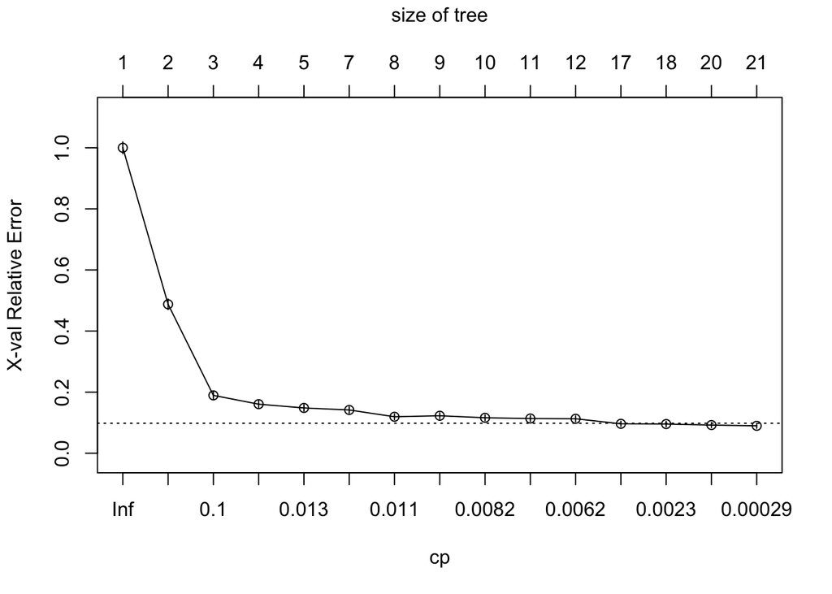

```r
plotcp(dat.tree)
```

### 1.2

Using the one-standard-error rule, the best `cp` value is 0.00247117, and the corresponding CV error is
$$0.54709\times 0.096376 = .05272635$$
.

### 1.3

Prune the tree with the best `cp`:

```r
best.cp <- 0.00247117
dat.pruned <- prune(dat.tree, cp=best.cp)
print(dat.pruned)
```

```
## n= 2219
##
## node), split, n, loss, yval, (yprob)
##       * denotes terminal node
##
##   1) root 2219 1214 1 (0.452906715 0.296529968 0.250563317)
##     2) V185>=-0.0015 1021   37 1 (0.963761019 0.014691479 0.021547502)
##       4) V45< -0.8665 989    6 1 (0.993933266 0.001011122 0.005055612) *
##       5) V45>=-0.8665 32   15 5 (0.031250000 0.437500000 0.531250000)
##        10) V108>=0.5705 13    1 3 (0.000000000 0.923076923 0.076923077) *
##        11) V108< 0.5705 19    3 5 (0.052631579 0.105263158 0.842105263) *
##     3) V185< -0.0015 1198  555 3 (0.017529215 0.536727880 0.445742905)
##       6) V77>=-0.9915 650   88 3 (0.000000000 0.864615385 0.135384615)
##        12) V86< 0.232 580   33 3 (0.000000000 0.943103448 0.056896552)
##          24) V25>=-0.989 560   17 3 (0.000000000 0.969642857 0.030357143)
##            48) V72< 0.9925 548    7 3 (0.000000000 0.987226277 0.012773723) *
##            49) V72>=0.9925 12    2 5 (0.000000000 0.166666667 0.833333333) *
##          25) V25< -0.989 20    4 5 (0.000000000 0.200000000 0.800000000) *
##        13) V86>=0.232 70   15 5 (0.000000000 0.214285714 0.785714286)
##          26) V55< -0.961 13    3 3 (0.000000000 0.769230769 0.230769231) *
##          27) V55>=-0.961 57    5 5 (0.000000000 0.087719298 0.912280702) *
##       7) V77< -0.9915 548  102 5 (0.038321168 0.147810219 0.813868613)
##        14) V71< -0.9995 149   81 5 (0.134228188 0.409395973 0.456375839)
##          28) V8>=0.2385 46    8 3 (0.021739130 0.826086957 0.152173913)
##            56) V15< -0.5115 39    1 3 (0.025641026 0.974358974 0.000000000) *
##            57) V15>=-0.5115 7    0 5 (0.000000000 0.000000000 1.000000000) *
##          29) V8< 0.2385 103   42 5 (0.184466019 0.223300971 0.592233010)
##            58) V186>=0.35 22    4 1 (0.818181818 0.045454545 0.136363636) *
##            59) V186< 0.35 81   23 5 (0.012345679 0.271604938 0.716049383)
##             118) V95>=-0.9115 7    0 3 (0.000000000 1.000000000 0.000000000) *
##             119) V95< -0.9115 74   16 5 (0.013513514 0.202702703 0.783783784)
##               238) V75>=-0.514 31   15 5 (0.000000000 0.483870968 0.516129032)
##                 476) V238< -0.6425 16    1 3 (0.000000000 0.937500000 0.062500000) *
##                 477) V238>=-0.6425 15    0 5 (0.000000000 0.000000000 1.000000000) *
##               239) V75< -0.514 43    1 5 (0.023255814 0.000000000 0.976744186) *
##        15) V71>=-0.9995 399   21 5 (0.002506266 0.050125313 0.947368421)
##          30) V95>=-0.4985 9    0 3 (0.000000000 1.000000000 0.000000000) *
##          31) V95< -0.4985 390   12 5 (0.002564103 0.028205128 0.969230769) *
```

Draw the tree:

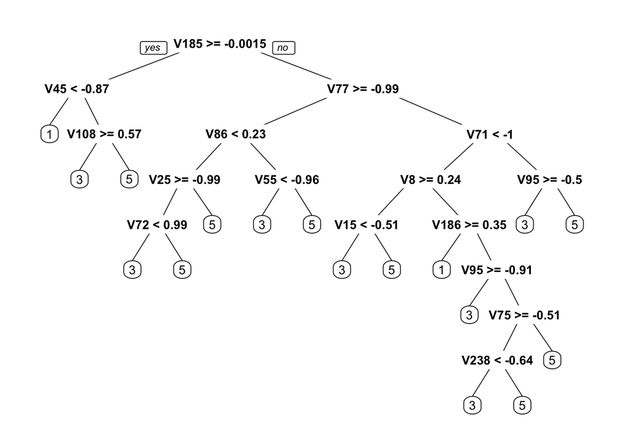

```r
library(rpart.plot)
prp(dat.pruned, roundint=F)
```

### 1.4

Apply the pruned tree to the test data:

```r
y.test.pruned <- predict(dat.pruned, dat$test, type="class")
mean(y.test.pruned != dat$test[,1])
```

```
## [1] 0.08983051
```

## Problem 2

### 2.1

Generate a bootstrap sample set:

```r
set.seed(20)
ind <- sample(1:nrow(dat$train),nrow(dat$train),replace=TRUE)
boot <- dat$train[ind,]
```

Number of distinct observations in the resampled dataset:

```r
length(unique(ind))
```

```
## [1] 1402
```

### 2.2

Train a classifcation tree and prune it using the best `cp` value obtained in Problem 1:

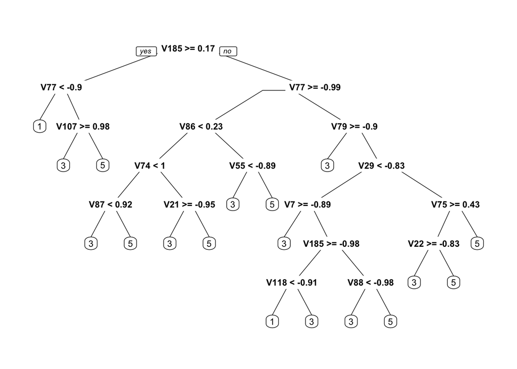

```r
dat.boot <- rpart(V1 ~ ., data=boot, method="class", control=rpart.control(cp=0.0001))
dat.boot <- prune(dat.boot, cp=best.cp)
prp(dat.boot, roundint=F)
```

Obviously, the tree is not the same as the tree obtained in Problem 1.

### 2.3

Train classification trees on 25 bootstrap sample sets:

```r
generate.trees <- function(t) {
  trees <- list()
  for (i in 1:t) {
    set.seed(i)
    ind <- sample(1:nrow(dat$train),nrow(dat$train),replace=TRUE)
    boot <- dat$train[ind,]
    dat.boot <- rpart(V1 ~ ., data=boot, method="class", control=rpart.control(cp=0.0001))
    dat.boot <- prune(dat.boot, cp=best.cp)
    trees[[i]] <- dat.boot
  }
  trees
}
```

```r
trees <- generate.trees(25)
test.errors <- sapply(trees, function(tr) {
  y.test.boot <- predict(tr, dat$test, type="class")
  mean(y.test.boot != dat$test[,1])
})
test.errors
```

```
##  [1] 0.08644068 0.08644068 0.08983051 0.08135593 0.09830508 0.09491525
##  [7] 0.08813559 0.10677966 0.09152542 0.07966102 0.11186441 0.09661017
## [13] 0.09661017 0.08474576 0.09830508 0.09322034 0.11186441 0.08983051
## [19] 0.09661017 0.08644068 0.09491525 0.07966102 0.09491525 0.08983051
## [25] 0.09661017
```

Mean test error rate:

```r
mean(test.errors)
```

```
## [1] 0.09301695
```

### 2.4

Use majority vote to get an aggregated classifier:

```r
bagging.test.err <- function(trees) {
  t <- length(trees)
  y.test.bag.mat <- matrix(0, nrow=nrow(dat$test), ncol=t)
  for (i in 1:t) y.test.bag.mat[,i] <- as.numeric(as.character(predict(trees[[i]], dat$test, type="class")))
  y.test.bag <- as.factor(sapply(1:nrow(dat$test), function(i) {
    tab <- table(y.test.bag.mat[i,])
    names(tab)[which.max(tab)]
  }))
  mean(y.test.bag != dat$test[,1])
}
bagging.test.err(trees)
```

```
## [1] 0.06610169
```

### 2.5

Try bagging with different `t` values:

```r
trees.tot <- generate.trees(40)
t.vals <- 1:40
test.errors <- c()
for (t in t.vals) {
  trees <- trees.tot[1:t]
  test.errors <- c(test.errors, bagging.test.err(trees))
}
test.errors
```

```
##  [1] 0.08644068 0.08813559 0.07796610 0.07966102 0.07796610 0.06949153
##  [7] 0.07796610 0.07288136 0.07288136 0.06779661 0.07288136 0.07118644
## [13] 0.06949153 0.06610169 0.06610169 0.06610169 0.07288136 0.06779661
## [19] 0.07288136 0.06949153 0.06949153 0.06779661 0.06949153 0.06779661
## [25] 0.06610169 0.06779661 0.06610169 0.06610169 0.06610169 0.06949153
## [31] 0.07118644 0.06949153 0.06779661 0.06949153 0.06949153 0.06779661
## [37] 0.06779661 0.06779661 0.06949153 0.06779661
```

Plot test error vs. `t` values:

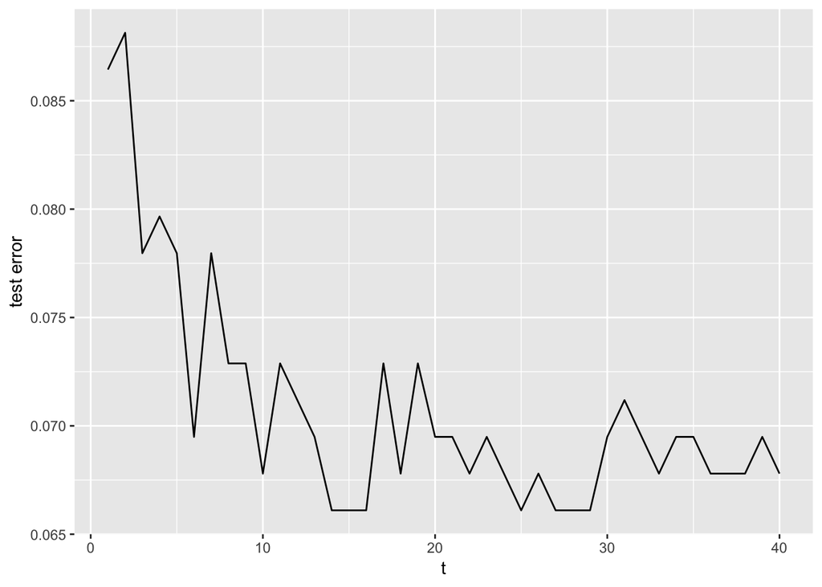

```r
library(ggplot2)
ggplot(data=data.frame(t.vals, test.errors), aes(t.vals, test.errors)) +
  geom_line() + labs(x="t", y="test error")
```

We notice that larger `t` value does not always lead to better result.

## Problem 3

### 3.1

Train a random forest and plot OOB error vs. number of trees:

```r
library(randomForest)
```

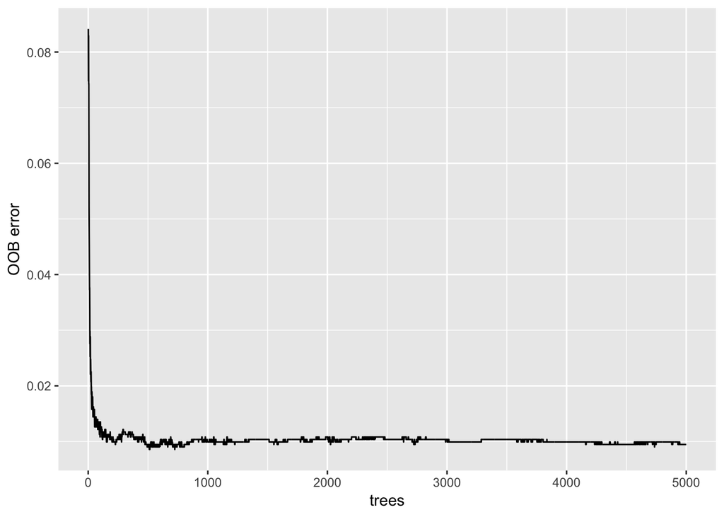

```r
set.seed(10)
dat.rf <- randomForest(V1 ~ ., data=dat$train, ntree=5000)
oob.errors <- dat.rf$err.rate[,1]
ggplot(data=data.frame(n=1:5000, oob.errors), aes(n, oob.errors)) +
  geom_line() + labs(x="trees", y="OOB error")
```

### 3.2

Calculate the lowest OOB error and corresponding number of trees:

```r
print(min(oob.errors))
```

```
## [1] 0.008562416
```

```r
which(oob.errors == min(oob.errors))
```

```
## [1] 511 512 514 515 724
```

### 3.3

Re-train the random forest using the optimum number of trees (511) obtained in Part 2:

```r
set.seed(10)
dat.rf <- randomForest(V1 ~ ., data=dat$train, ntree=511)
y.test.rf <- predict(dat.rf, dat$test, type="response")
mean(y.test.rf != dat$test[,1])
```

```
## [1] 0.03559322
```

## Problem 4

### 4.1

Use k-means clustering to cluster the training data with `k`=3, and report the number of samples in each cluster

```r
set.seed(10)
dat.kmeans <- kmeans(dat$train[,-1], 3, nstart=20)
dat.kmeans$size
```

```
## [1]  566  635 1018
```

### 4.2

Plot the average image of each cluster:

[figure not shown]

[figure not shown]

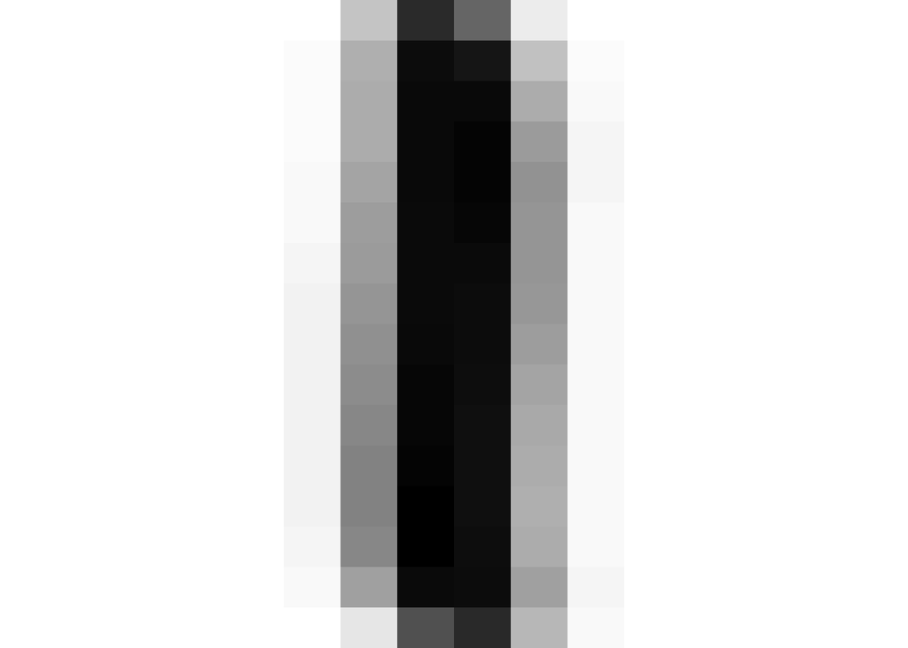

```r
conv.image <- function(vec)
{
mat <- matrix(as.numeric(vec), nrow=16, ncol=16)
mat <- -mat[, 16 : 1]
par(mar=c(0, 0, 0, 0))
image(mat, col=gray(seq(0, 1, 0.01)), xaxt='n', yaxt='n')
}

for (i in 1:3) conv.image(dat.kmeans$centers[i,])
```

### 4.3

Use the gap statistic to find the best `k`:

```r
library(cluster)
set.seed(10)
system.time(dat.kmeans <- clusGap(dat$train[,-1], FUNcluster=kmeans, nstart=20, K.max=10, B=50))
```

```
##     user   system  elapsed
## 1128.616   23.559 1153.567
```

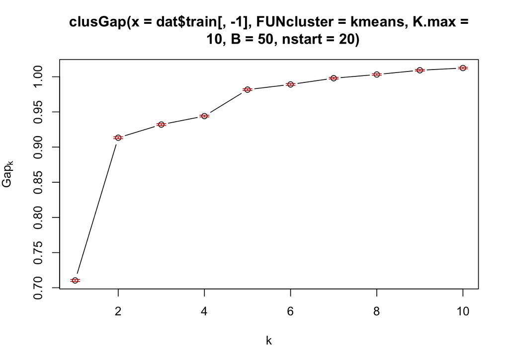

```r
plot(dat.kmeans)
```

Using Tibshirani et al.’s “1-sd rule”, the best `k` is 10:

```r
print(dat.kmeans, method="Tibs2001SEmax")
```

```
## Clustering Gap statistic ["clusGap"] from call:
## clusGap(x = dat$train[, -1], FUNcluster = kmeans, K.max = 10,     B = 50, nstart = 20)
## B=50 simulated reference sets, k = 1..10; spaceH0="scaledPCA"
##  --> Number of clusters (method 'Tibs2001SEmax', SE.factor=1): 10
##           logW   E.logW       gap      SE.sim
##  [1,] 8.891823 9.602189 0.7103659 0.001430615
##  [2,] 8.660887 9.574183 0.9132963 0.001390745
##  [3,] 8.626702 9.558716 0.9320141 0.001233773
##  [4,] 8.602378 9.546463 0.9440850 0.001219064
##  [5,] 8.556380 9.538099 0.9817192 0.001240007
##  [6,] 8.541369 9.530460 0.9890908 0.001255413
##  [7,] 8.526829 9.524774 0.9979454 0.001175452
##  [8,] 8.516163 9.519371 1.0032074 0.001081645
##  [9,] 8.505855 9.515112 1.0092564 0.001085737
## [10,] 8.498774 9.511195 1.0124216 0.001102228
```

## Problem 5

### 5.1

Apply hierarchical clustering with the single linkage:

```r
dat.dist <- dist(dat$train[,-1], method="euclidean")
dat.hc.single <- cutree(hclust(dat.dist, method="single"), 3)
table(dat.hc.single)
```

```
## dat.hc.single
##    1    2    3
## 2217    1    1
```

Apply hierarchical clustering with the complete linkage:

```r
dat.hc.complete <- cutree(hclust(dat.dist, method="complete"), 3)
table(dat.hc.complete)
```

```
## dat.hc.complete
##    1    2    3
##  102  565 1552
```

Apply hierarchical clustering with the group average linkage:

```r
dat.hc.average <- cutree(hclust(dat.dist, method="average"), 3)
table(dat.hc.average)
```

```
## dat.hc.average
##    1    2    3
## 2190   27    2
```

### 5.2

Representative images for each cluster with the single linkage:

[figure not shown]

[figure not shown]

[figure not shown]

```r
mean.images <- function(clusters) {
  for (i in 1:3) conv.image(colMeans(as.matrix(dat$train[clusters==i,-1])))
}
mean.images(dat.hc.single)
```

Representative images for each cluster with the complete linkage:

[figure not shown]

[figure not shown]

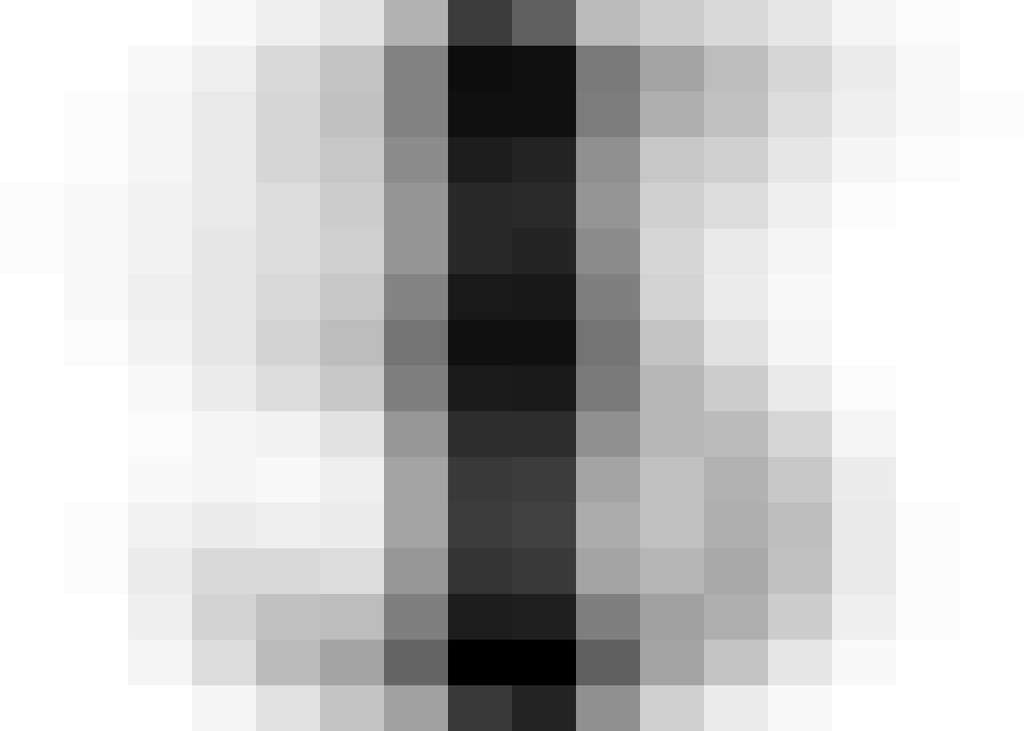

```r
mean.images(dat.hc.complete)
```

Representative images for each cluster with the group average linkage:

[figure not shown]

[figure not shown]

[figure not shown]

```r
mean.images(dat.hc.average)
```